# Description

[figure not shown]

## Question 01

- Which clinical features and which blood biomarkers are associated with incident diabetes? (These clinical features and biomarkers can potentially be risk or protective factors for diabetes development.)

**Hints:**

1. Remove subjects with existing diabetes for this analysis.
2. You can consider incident diabetes as a binary outcome and use logistic regressions; or if you want to try survival analysis,you can use Cox regressions utilizing the provided time-to-event information.
3. Investigate each individual features and biomarkers and use p-values to justify your findings.
4. For blood biomarkers, use transformation that is robust when there are outliers present.
5. Demonstrate your findings with visualization.

## Question 02

- How can we use blood biomarkers alone to predict the risk of developing diabetes?

**Hints:**

1. Select the relevant blood biomarkers as features for your classifier.
2. Select and train a ML model to make predictions.
3. Evaluate your predictive model with ROCAUC.

## Question 03

- Are there any clusters based on blood biomarkers among the participants who developed incident diabetes?
- Can you identify which blood biomarkers defined these clusters?

**Hints:**

1. Use the subset of subjects who developed incident diabetes for your unsupervised learning.
2. You can choose to use all or only relevant biomarkers for clustering.
3. Select one approach to identify clusters of these subjects.
4. Identify top blood biomarkers that contributed to the clustering.

References:

- https://github.com/YousefGh/kmeans-feature-importance

# Import the modules

```python
import time
time_start_notebook = time.time()
```

```python
import numpy as np
import pandas as pd
import os,sys,time

# visualization
import matplotlib.pyplot as plt
import seaborn as sns
sns.set()

# modules
import missingno as msno
import pandas_profiling
from pandas_profiling import ProfileReport
from tqdm import tqdm

# modelling
import sklearn
from sklearn.model_selection import train_test_split
from sklearn.preprocessing import RobustScaler

# statsmodel
import statsmodels.api as sm
import statsmodels.formula.api as smf
from statsmodels.iolib.smpickle import load_pickle

# model evaluation
import scikitplot
from scikitplot import metrics as skpmetrics
import collections

# settings
SEED = 100
pd.set_option('max_columns',100)

%matplotlib inline
%load_ext watermark
%watermark -iv
```

```
The watermark extension is already loaded. To reload it, use:
  %reload_ext watermark
sklearn          0.23.1
statsmodels.api  0.12.2
pandas_profiling 2.11.0
seaborn          0.11.0
pandas           1.3.0
scikitplot       0.3.7
numpy            1.19.5
missingno        0.4.2
```

```python
# my local library
import sys
sys.path.append("/Users/poudel/Dropbox/a00_Bhishan_Modules/bhishan")
from bhishan import bp
```

# Load the data

```python
!ls ~/data
```

```
X_test_under_scaled.npz       first_10.csv
X_train_under_scaled.npz      ser_dtype.csv
df_under_features.csv         ser_ytest_under.csv
diabetes_project_dataset.csv  ser_ytrain_under.csv
diabetes_project_dataset.hdf5
```

```python
df_features = pd.read_csv(os.path.expanduser("~/data/df_under_features.csv"))
df_features.head(2)
```

|  | 0 |
| --- | --- |
| 0 | diabetes_time |
| 1 | age |

```python
features = df_features.iloc[:,0].to_list()
features[:5], len(features)
```

```
(['diabetes_time', 'age', 'male', 'BMI', 'HDL'], 94)
```

```python
%%time

# read numpy pickled files
p = os.path.expanduser("~/data/X_train_under_scaled.npz")
X_train_under_scaled = np.load(p)['data']

p = os.path.expanduser("~/data/X_test_under_scaled.npz")
X_test_under_scaled = np.load(p)['data']

X_train_under_scaled.shape, X_test_under_scaled.shape
```

```
CPU times: user 8.77 ms, sys: 2.32 ms, total: 11.1 ms
Wall time: 18.7 ms
```

```
((1126, 94), (282, 94))
```

```python
# read pandas series
ser_ytrain_under = pd.read_csv(os.path.expanduser("~/data/ser_ytrain_under.csv"))
ser_ytrain_under = ser_ytrain_under.set_index("index")

ser_ytest_under = pd.read_csv(os.path.expanduser("~/data/ser_ytest_under.csv"))
ser_ytest_under = ser_ytest_under.set_index("index")

ser_ytrain_under.head()
```

| index | incident_diabetes |
| --- | --- |
| 658 | 0 |
| 1250 | 1 |
| 655 | 0 |
| 809 | 1 |
| 483 | 0 |

# Select only biomarkers

```python
print(features)
```

[output not shown]

```python
cols_mtb = [i for i in features if i.startswith('mtb')]
cols_mtb[:2], len(cols_mtb)
```

```
(['mtb_1368087', 'mtb_1380093'], 77)
```

```python
num_exclude = len(features) - len(cols_mtb)
num_exclude
```

```
17
```

```python
len(features[num_exclude:])
```

```
77
```

```python
X = np.r_[X_train_under_scaled[:,num_exclude:],
          X_test_under_scaled[:,num_exclude:]
         ]
X.shape
```

```
(1408, 77)
```

```python
y = np.r_[ser_ytrain_under.values, ser_ytest_under.values]
y.shape
```

```
(1408, 1)
```

```python
features_bio = features[num_exclude:]
features_bio[:5], len(features_bio), X.shape[1]
```

```
(['mtb_1368087', 'mtb_1380093', 'mtb_1812369', 'mtb_1838668', 'mtb_1042362'],
 77,
 77)
```

# Modelling kmeans clustering (no train-test split for unsupervised algos)

```python
from sklearn.cluster import KMeans
```

## find best number of clusters

- https://www.kaggle.com/emilytries/clustering-and-feature-selection

```python
import plotly.graph_objects as go
```

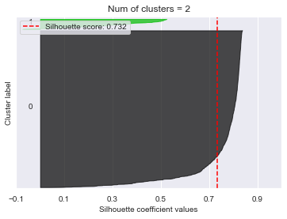

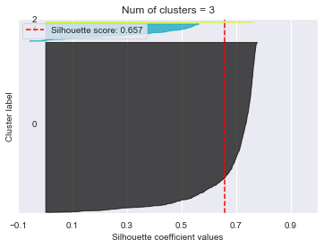

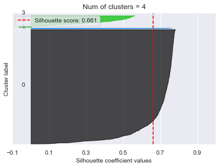

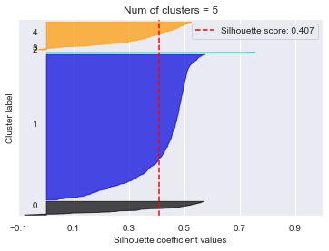

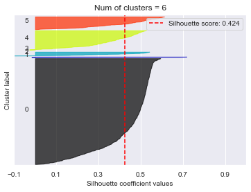

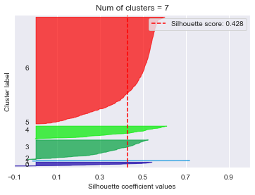

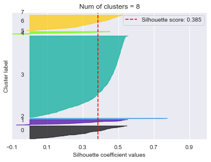

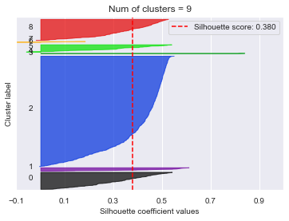

```python
wcss = []

for i in range(2, 10):
    kmeans = KMeans(n_clusters=i,init="k-means++",max_iter=500,n_init=10,random_state=SEED)
    kmeans.fit(X)
    wcss.append(kmeans.inertia_)
    skpmetrics.plot_silhouette(X,kmeans.labels_,title=f"Num of clusters = {i}")
```

```python
fig = go.Figure(data=go.Scatter(x=list(range(1,10)), y=wcss))

fig.update_layout(title='Elbow method',
                   xaxis_title='Number of Clusters',
                   yaxis_title='WCSS')

fig['layout']['title_x'] = 0.5
fig.show()
```

[interactive chart not shown]

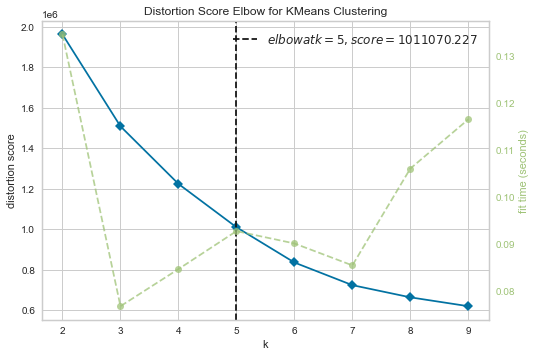

```python
from yellowbrick.cluster import KElbowVisualizer

kmeans = KMeans(init="k-means++",max_iter=500,n_init=10,random_state=SEED)
visu = KElbowVisualizer(kmeans, k=(2, 10))
visu.fit(X)
visu.show();
```

```python
# choose appropriate number of clusters
n_clusters = 2
```

```python
kmeans = KMeans(n_clusters=n_clusters,
                init="k-means++",max_iter=500,
                n_init=10,
                random_state=SEED)

idx_clusters = kmeans.fit_predict(X)

idx_clusters[:5]
```

```
array([0, 0, 0, 0, 0], dtype=int32)
```

```python
np.bincount(idx_clusters)
```

```
array([1322,   86])
```

```python
collections.Counter(idx_clusters)
```

```
Counter({0: 1322, 1: 86})
```

```python
bp.show_methods(skpmetrics)
```

|  | 0 | 1 | 2 |
| --- | --- | --- | --- |
| 0 | LabelEncoder | itertools | plot_roc_curve |
| 1 | absolute_import | label_binarize | plot_silhouette |
| 2 | auc | plot_calibration_curve | precision_recall_curve |
| 3 | average_precision_score | plot_confusion_matrix | print_function |
| 4 | binary_ks_curve | plot_cumulative_gain | roc_curve |
| 5 | calibration_curve | plot_ks_statistic | silhouette_samples |
| 6 | confusion_matrix | plot_lift_curve | silhouette_score |
| 7 | cumulative_gain_curve | plot_precision_recall | unicode_literals |
| 8 | deprecated | plot_precision_recall_curve | unique_labels |
| 9 | division | plot_roc | validate_labels |
| 10 | interp |  |  |

## silhouette score plot

- https://scikit-learn.org/stable/auto_examples/cluster/plot_kmeans_silhouette_analysis.html#sphx-glr-auto-examples-cluster-plot-kmeans-silhouette-analysis-pym

```python
# skpmetrics.plot_silhouette?
```

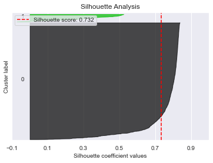

```python
skpmetrics.plot_silhouette(X,idx_clusters);
```

```python
idx_clusters[:5]
```

```
array([0, 0, 0, 0, 0], dtype=int32)
```

```python
# from question 2, we had found that following two biomarkers were most imoportant
# 'mtb_18470', 'mtb_606773',

imp_feats = ['mtb_18470', 'mtb_606773', 'mtb_1368087',
                      'mtb_509192', 'mtb_1230298', 'mtb_18464',
                      'mtb_1391826', 'mtb_1435571', 'mtb_590255',
                      'mtb_1940724', 'mtb_1228672', 'mtb_18350', 'mtb_18327']
```

```python
features[num_exclude:].index('mtb_1368087')
```

```
0
```

```python
idx_imp_feats = [features[num_exclude:].index(i) for i in imp_feats]
idx_imp_feats[:5]
```

```
[58, 14, 0, 20, 21]
```

```python
centroids = kmeans.cluster_centers_
centroids.shape
```

```
(2, 77)
```

```python
center_x0 = centroids[0,idx_imp_feats[0]]
center_y0 = centroids[1,idx_imp_feats[0]]

center_x1 = centroids[0,idx_imp_feats[1]]
center_y1 = centroids[1,idx_imp_feats[1]]

center_x0, center_y0
```

```
(0.22513945817974862, 0.7682914905100586)
```

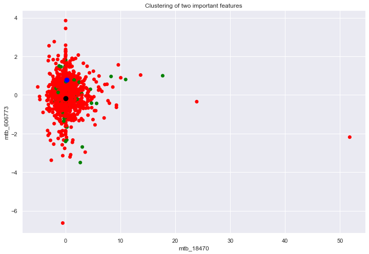

[output not shown]

```python
plt.figure(figsize=(12,8))
plt.scatter(x=X[:,idx_imp_feats[0]],
            y=X[:,idx_imp_feats[1]],
            c=['red' if i == 0 else 'green' for i in idx_clusters])

plt.scatter(center_x0,center_y0,color='blue',s=80)
plt.scatter(center_x1,center_y1,color='black',s=80)

plt.xlabel(imp_feats[0])
plt.ylabel(imp_feats[1])
plt.title("Clustering of two important features")
plt.show()

print("center of labels 0 (red) is blue and center of labels 1 (green) is black.")
```

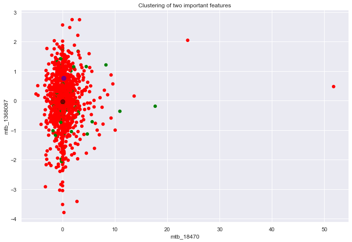

```python
m,n = 0,2 # important feature index

plt.figure(figsize=(12,8))
plt.scatter(x=X[:,idx_imp_feats[0]],
            y=X[:,idx_imp_feats[2]],
            c=['red' if i == 0 else 'green' for i in idx_clusters])

plt.scatter(centroids[0,idx_imp_feats[m]],centroids[1,idx_imp_feats[m]],color='blue',s=80,alpha=0.5)
plt.scatter(centroids[0,idx_imp_feats[n]],centroids[1,idx_imp_feats[n]],color='black',s=80,alpha=0.5)

plt.xlabel(imp_feats[m])
plt.ylabel(imp_feats[n])
plt.title("Clustering of two important features")
plt.show()
```

# Hierarchical clustering

- https://stackabuse.com/hierarchical-clustering-with-python-and-scikit-learn/
- https://www.analyticsvidhya.com/blog/2019/05/beginners-guide-hierarchical-clustering/

```python
import plotly.figure_factory as ff
import scipy.cluster.hierarchy as sch
```

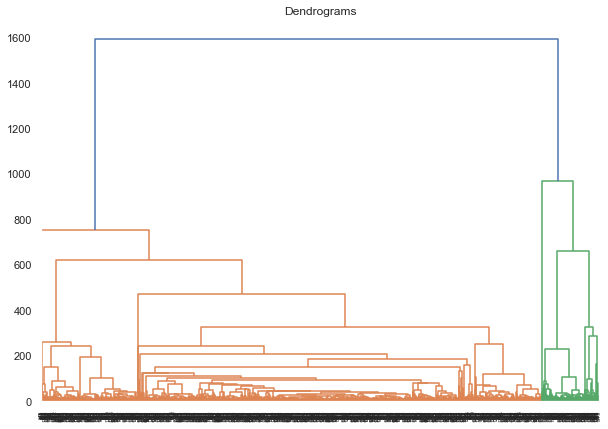

```python
plt.figure(figsize=(10, 7))
plt.title("Dendrograms")
dend = sch.dendrogram(sch.linkage(X, method='ward'))
```

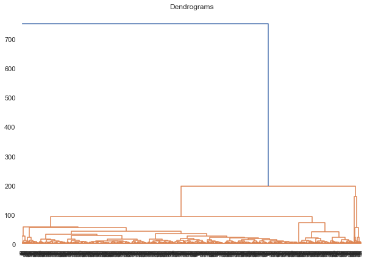

```python
plt.figure(figsize=(10, 7))
plt.title("Dendrograms")
dend = sch.dendrogram(sch.linkage(X[:,idx_imp_feats],
                    method='ward')
                     )
```

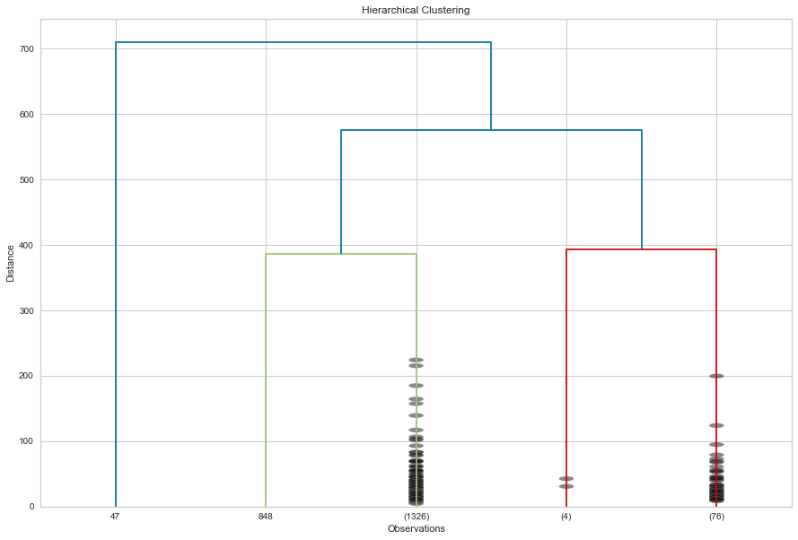

```python
# Create 5 clusters
hc_complete = sch.linkage(X, "complete")

plt.figure(figsize=(15, 10))
plt.title("Hierarchical Clustering")
plt.xlabel("Observations")
plt.ylabel("Distance")
sch.dendrogram(hc_complete,
           truncate_mode="lastp",
           p=5,
           show_contracted=True,
           leaf_font_size=10)
plt.show()
```

# Feature importance of clustering

- https://github.com/YousefGh/kmeans-feature-importance

## Using 2 clusters

```python
sys.path.append(os.path.expanduser("~/Dropbox/a01_Resources/kmeans_interp"))

from kmeans_feature_imp import KMeansInterp
```

```python
kmeans_int = KMeansInterp(n_clusters=2,
                   random_state=SEED,
                   ordered_feature_names=features_bio,
                   feature_importance_method='wcss_min',
                  )

kmeans_int.fit(X)

labels = kmeans_int.labels_
```

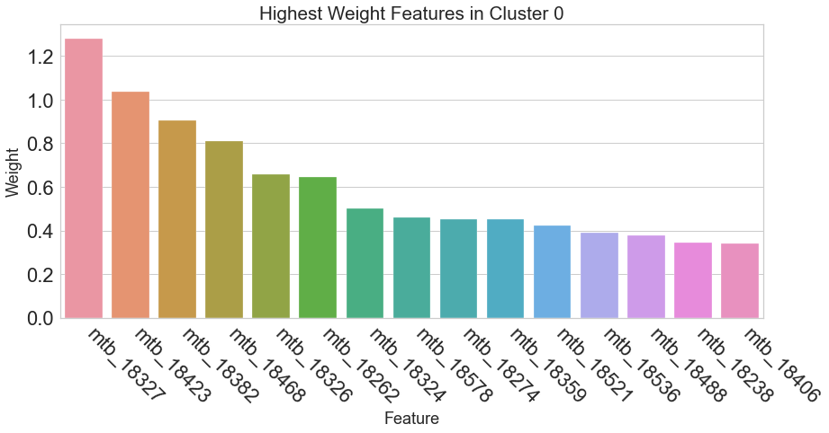

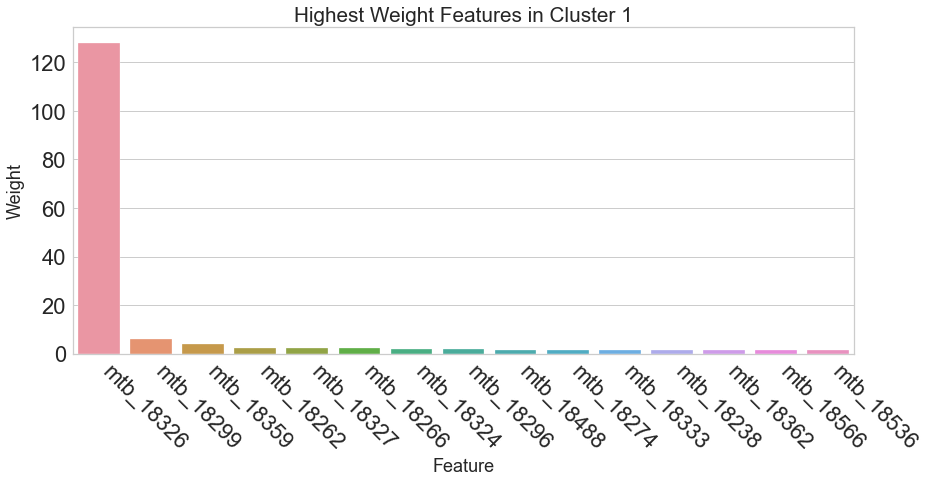

```python
for cluster_label, feature_weights in kmeans_int.feature_importances_.items():
    df_feature_weight = pd.DataFrame(feature_weights[:15], columns=["Feature", "Weight"])
    fig, ax = plt.subplots(figsize=(14,6))
    sns.barplot(x="Feature", y="Weight", data=df_feature_weight)
    plt.xticks(rotation=-45, ha="left");
    ax.tick_params(axis='both', which='major', labelsize=22)
    plt.title(f'Highest Weight Features in Cluster {cluster_label}', fontsize='xx-large')
    plt.xlabel('Feature', fontsize=18)
    plt.ylabel('Weight', fontsize=18)

    plt.show();

    print('\n\n')
```

## Using 5 clusters

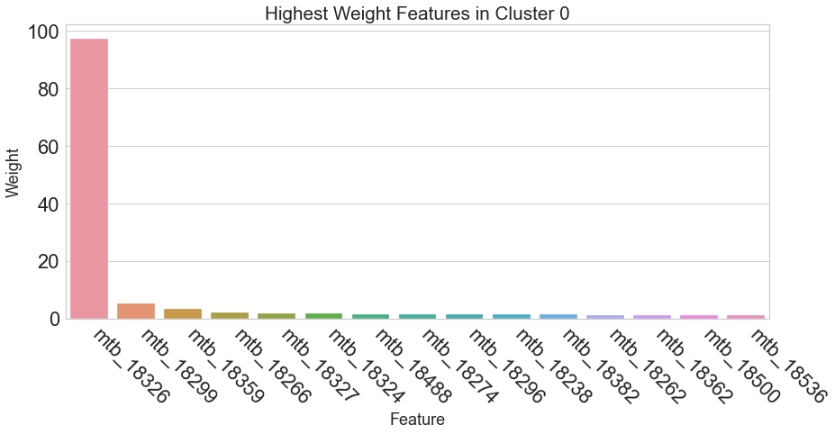

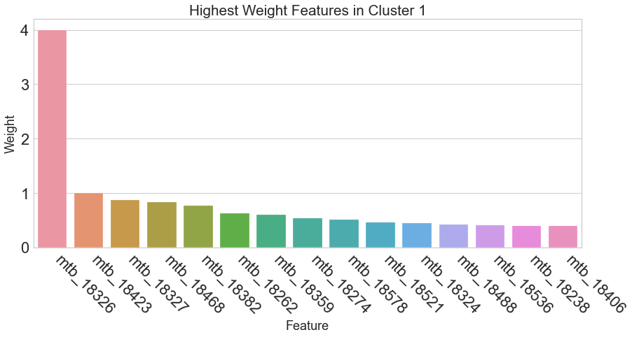

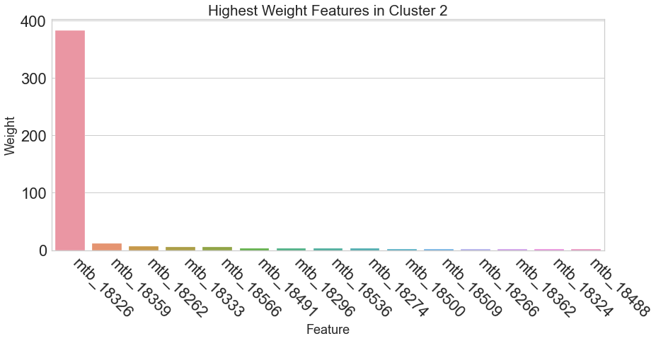

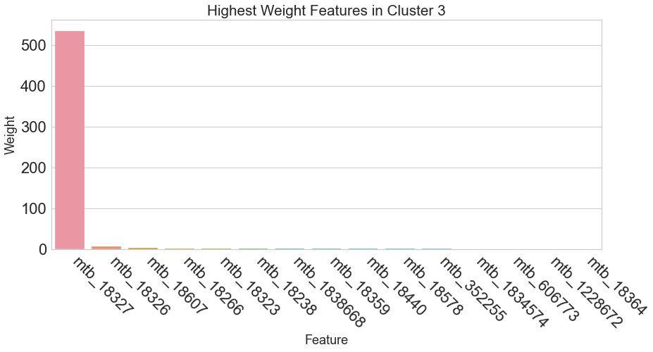

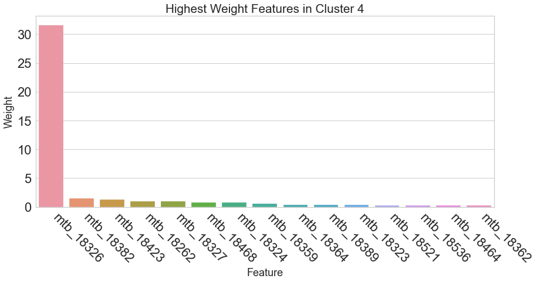

```python
kmeans_int = KMeansInterp(n_clusters=5,
                   random_state=SEED,
                   ordered_feature_names=features_bio,
                   feature_importance_method='wcss_min',
                  )

kmeans_int.fit(X)

labels = kmeans_int.labels_

for cluster_label, feature_weights in kmeans_int.feature_importances_.items():
    df_feature_weight = pd.DataFrame(feature_weights[:15], columns=["Feature", "Weight"])
    fig, ax = plt.subplots(figsize=(14,6))
    sns.barplot(x="Feature", y="Weight", data=df_feature_weight)
    plt.xticks(rotation=-45, ha="left");
    ax.tick_params(axis='both', which='major', labelsize=22)
    plt.title(f'Highest Weight Features in Cluster {cluster_label}', fontsize='xx-large')
    plt.xlabel('Feature', fontsize=18)
    plt.ylabel('Weight', fontsize=18)

    plt.show();

    print('\n\n')
```